# Communicate Data Finding

Ford GoBike System Data

## by Rinad Bankher

## Investigation Overview

This project has two parts that demonstrate the importance and value of data visualization techniques in the data analysis process. In the first part, you will use Python visualization libraries to systematically explore a selected dataset, starting from plots of single variables and building up to plots of multiple variables. In the second part, you will produce a short presentation that illustrates interesting properties, trends, and relationships that you discovered in your selected dataset. The primary method of conveying your findings will be through transforming your exploratory visualizations from the first part into polished, explanatory visualizations.

## Dataset Overview

Ford GoBike is a regional public bicycle sharing system located in San Francisco Bay Area. This dataset shows history data of individual rides made in a bike-sharing system at 2019.

### What is the structure of your dataset?

> The cleaned dataset has 171617 rows and 2 columns (user_type and member_gender) with 3 additional columns by feature engineering (member_age, hours, and weekdays).

### What is/are the main feature(s) of interest in your dataset?

> - Age
> - Gender
> - Membership Status
> - Weekday
> - Hour

## Q1. What is the relation between users age and their gender?

> The male and female median ages are close to each other, whereas the other gender is slightly higher. We can see that females in nearly 30s tend to ride bikes than all different genders. Another thing to notice is the other gender has more users at age 50s.

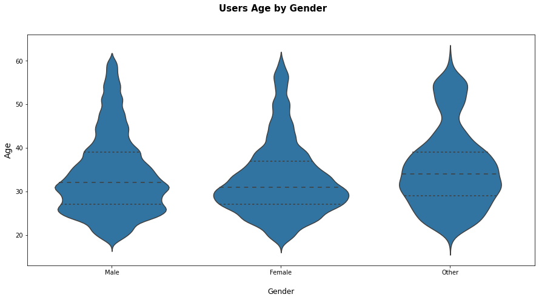

## Q2. Does the number of users gender differ between users type?

> The result shows that the range of the y-axis of subscriber user type is higher than the customer. Also, for each user type, most users were male.

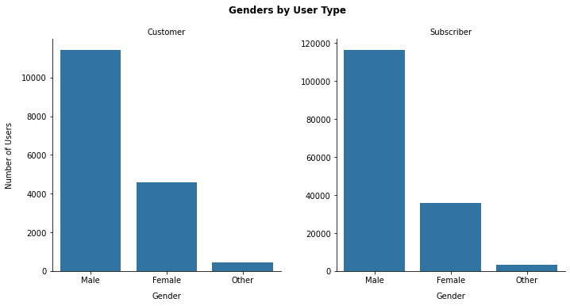

## Q3. Does users age distribution differ between users type?

> The distributions show the Majority of users fall between 28 to 33 years old for both user types.

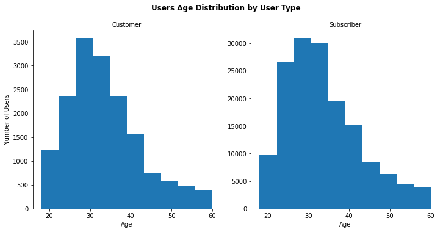

## Q4. What is the weekly usage for each user type?

> The two distributions show weekdays have high number of rides than weekends. But, compared with subscribers, customers are more likely to ride bikes on weekends.

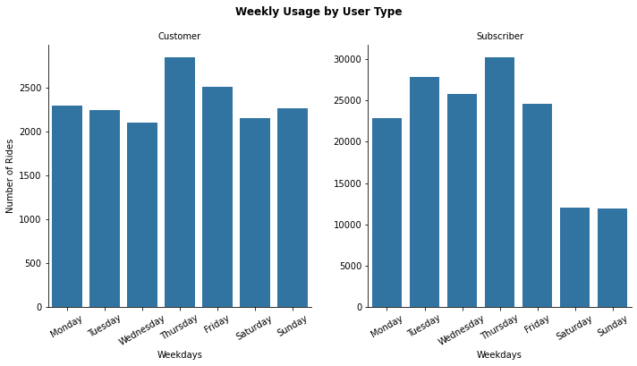

## Q5. Would hourly usage be the same for the different users type?

> It seems like customers ride bikes often between 5-6 PM, while subscribers ride bikes during rush hours (8-9 AM and 5-6 PM).

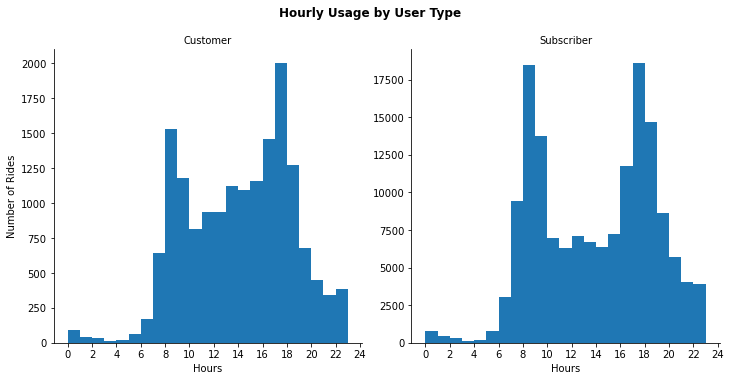

## Q6. What is the weekly bike usage by users type and genders?

> The plot supports the previous bivariate plots. For both user types, Most users were Male. The weekdays have high number of rides for both user types.

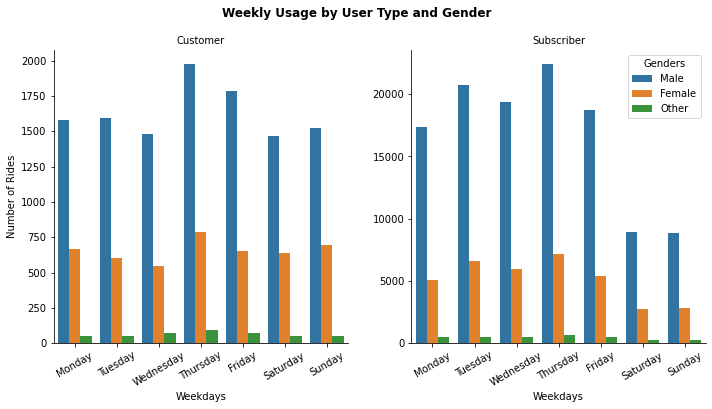

## Q7. What is the Hourly usage by users type and genders?

> Also, This plot supports the previous bivariate plots. Customers users ride bikes often between 5-6 PM, while subscribers ride bikes during rush hours (8-9 AM and 5-6 PM).

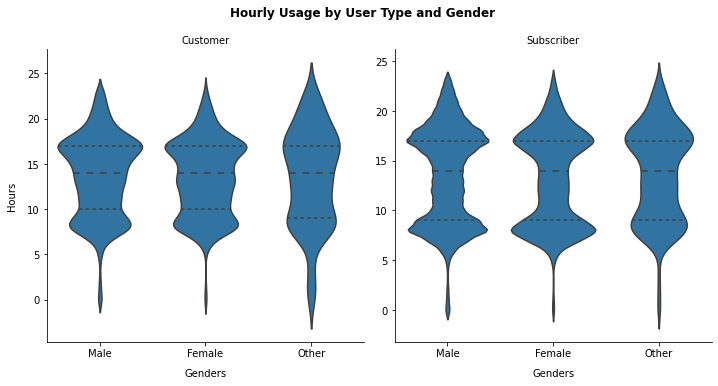

## Q8. How is the bike usage distributed on hours and weekdays for customers and subscribers?

> The plot also shows patterns as the two previous plots.

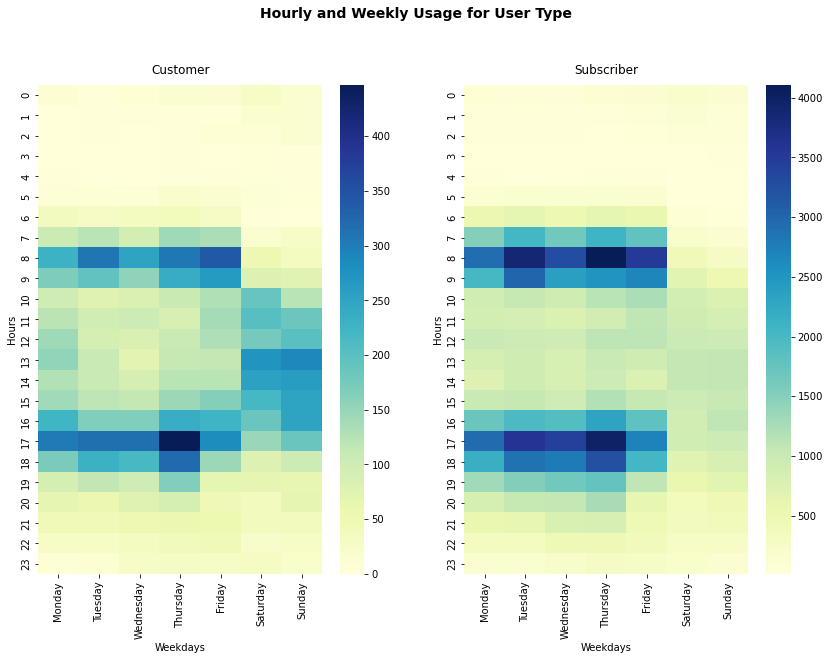

### Talk about some of the relationships you observed in this part of the investigation. Were there features that strengthened each other in terms of looking at your feature(s) of interest?

> The multivariate exploring section did support and prove the founding in the bivariate section. I also notice customers are more likely to ride bikes on weekends, which consider a chance for the company to increase its customer users. I found this point is interesting as I think customer users ride the bike other than for work, unlike subscribe users.